# Modelo Predicción - NBA

Sergio Casares Fernandez

28/10/2020

# **Introducción al trabajo:**

1:Player Nombre del jugador.

2:Salary Salario del jugador.

3:NBA_Country Nacionalidad del jugador.

4:NBA_DraftNumber Número del draft.

5:Age Edad del jugador.

6:Tm Abreviatura del equipo

7:G Partidos jugados

8:MP Minutos jugados

9:PER Eficiencia de jugador

10:TS% Porcentaje de tiro

11:3PAr % de triples

12:FTr % de tiros libres

13:ORB% % Rebotes Ofensivos ganados

14:DRB% % Rebotes defensivos ganados

15:TRB% % Rebotes totales

16:AST% % Asistencia

17:STL% % Robos

18:BLK% % Bloqueos

19:TOV% % Robo previo a tiro

20:USG% % de participacion en jugadas

21:OWS Acciones en ataque acertadas

22:DWS Acciones defensivas acertadas

23:WS Victorias contribuidas

24:WS/48 Ratio de contribución por partido

25:OBPM +/- rendimiento respecto al equipo (cada 100 jugadas en ataque)

26:DBPM +/- rendimiento respecto al equipo (cada 100 jugadas en defensa)

27:BPM +/- rendimiento respecto al equipo (cada 100 posesiones generales)

28:VORP Valor respecto a jugador involucrado en el cambio

Para poder comenzar a trabajar con el modelo, debemos instalar las librerías necesarias e importar el archivo donde se encuentra la información

```r
library(tidyverse)
library(fBasics)
library(car)
library(dplyr)
library(ggplot2)
library(knitr)
library(MASS)
library(corrplot)
library(PerformanceAnalytics)
library(gvlma)

nba <- read_delim("nba_2.csv", ";", escape_double = FALSE,
                    trim_ws = TRUE)

attach(nba)
head(nba)
```

| Player | Salary | NBA_Country | NBA_DraftNumber | Age | Tm | G | MP | PER | TS | PAr | FTr | ORB | DRB | TRB | AST | STL | BLK | TOV | USG | OWS | DWS | WS | WS_1 | OBPM | DBPM | BPM | VORP |
| --- | --- | --- | --- | --- | --- | --- | --- | --- | --- | --- | --- | --- | --- | --- | --- | --- | --- | --- | --- | --- | --- | --- | --- | --- | --- | --- | --- |
| Zhou Qi | 815615 | China | 43 | 22 | HOU | 16 | 87 | 0.6 | 0.303 | 0.593 | 0.370 | 6.5 | 16.8 | 11.7 | 1.5 | 1.1 | 6.8 | 18.2 | 19.5 | -0.4 | 0.1 | -0.2 | -0.121 | -10.6 | 0.5 | -10.1 | -0.2 |
| Zaza Pachulia | 3477600 | Georgia | 42 | 33 | GSW | 66 | 937 | 16.8 | 0.608 | 0.004 | 0.337 | 11.0 | 25.0 | 18.5 | 15.4 | 1.9 | 1.3 | 19.3 | 17.2 | 1.7 | 1.4 | 3.1 | 0.160 | -0.6 | 1.3 | 0.8 | 0.7 |
| Zach Randolph | 12307692 | USA | 19 | 36 | SAC | 59 | 1508 | 17.3 | 0.529 | 0.193 | 0.140 | 7.0 | 23.8 | 15.0 | 14.9 | 1.4 | 0.6 | 12.5 | 27.6 | 0.3 | 1.1 | 1.4 | 0.046 | -0.6 | -1.3 | -1.9 | 0.0 |
| Zach LaVine | 3202217 | USA | 13 | 22 | CHI | 24 | 656 | 14.6 | 0.499 | 0.346 | 0.301 | 1.4 | 14.4 | 7.7 | 18.6 | 1.8 | 0.5 | 9.7 | 29.5 | -0.1 | 0.5 | 0.4 | 0.027 | -0.7 | -2.0 | -2.6 | -0.1 |
| Zach Collins | 3057240 | USA | 10 | 20 | POR | 62 | 979 | 8.2 | 0.487 | 0.387 | 0.146 | 4.9 | 18.3 | 11.7 | 7.3 | 0.8 | 2.5 | 15.6 | 15.5 | -0.4 | 1.2 | 0.8 | 0.038 | -3.7 | 0.9 | -2.9 | -0.2 |
| Yogi Ferrell | 1312611 | USA | 62 | 24 | DAL | 79 | 2238 | 11.5 | 0.543 | 0.489 | 0.141 | 1.3 | 11.3 | 6.1 | 13.3 | 1.4 | 0.3 | 9.1 | 17.0 | 1.6 | 1.6 | 3.1 | 0.067 | -0.4 | -0.5 | -0.9 | 0.6 |

```r
summary(nba)
```

```
##     Player              Salary         NBA_Country        NBA_DraftNumber
##  Length:485         Min.   :   46080   Length:485         Min.   : 1.00
##  Class :character   1st Qu.: 1471382   Class :character   1st Qu.:11.00
##  Mode  :character   Median : 3202217   Mode  :character   Median :25.00
##                     Mean   : 6636507                      Mean   :29.45
##                     3rd Qu.:10000000                      3rd Qu.:47.00
##                     Max.   :34682550                      Max.   :62.00
##
##       Age             Tm                  G               MP
##  Min.   :19.00   Length:485         Min.   : 1.00   Min.   :   1
##  1st Qu.:23.00   Class :character   1st Qu.:29.00   1st Qu.: 381
##  Median :26.00   Mode  :character   Median :59.00   Median :1134
##  Mean   :26.26                      Mean   :50.17   Mean   :1154
##  3rd Qu.:29.00                      3rd Qu.:71.00   3rd Qu.:1819
##  Max.   :41.00                      Max.   :79.00   Max.   :2898
##
##       PER               TS              PAr              FTr
##  Min.   :-41.10   Min.   :0.0000   Min.   :0.0000   Min.   :0.0000
##  1st Qu.:  9.80   1st Qu.:0.5055   1st Qu.:0.1670   1st Qu.:0.1550
##  Median : 13.20   Median :0.5450   Median :0.3460   Median :0.2310
##  Mean   : 13.26   Mean   :0.5354   Mean   :0.3374   Mean   :0.2634
##  3rd Qu.: 16.50   3rd Qu.:0.5825   3rd Qu.:0.4810   3rd Qu.:0.3195
##  Max.   :134.10   Max.   :1.5000   Max.   :1.0000   Max.   :5.3330
##                   NA's   :2        NA's   :2        NA's   :2
##       ORB              DRB             TRB              AST
##  Min.   : 0.000   Min.   : 0.00   Min.   : 0.000   Min.   : 0.00
##  1st Qu.: 1.800   1st Qu.:10.20   1st Qu.: 6.200   1st Qu.: 6.90
##  Median : 3.200   Median :14.00   Median : 8.700   Median : 9.90
##  Mean   : 4.874   Mean   :14.95   Mean   : 9.908   Mean   :12.95
##  3rd Qu.: 7.000   3rd Qu.:18.80   3rd Qu.:13.300   3rd Qu.:17.60
##  Max.   :35.900   Max.   :37.60   Max.   :26.500   Max.   :49.40
##
##       STL              BLK              TOV             USG
##  Min.   : 0.000   Min.   : 0.000   Min.   : 0.00   Min.   : 0.0
##  1st Qu.: 1.000   1st Qu.: 0.600   1st Qu.: 9.90   1st Qu.:15.0
##  Median : 1.500   Median : 1.200   Median :12.50   Median :17.9
##  Mean   : 1.529   Mean   : 1.713   Mean   :13.14   Mean   :18.9
##  3rd Qu.: 1.900   3rd Qu.: 2.200   3rd Qu.:15.75   3rd Qu.:22.2
##  Max.   :12.500   Max.   :13.400   Max.   :66.70   Max.   :45.1
##                                    NA's   :2
##       OWS              DWS              WS              WS_1
##  Min.   :-2.300   Min.   :0.000   Min.   :-1.200   Min.   :-1.06300
##  1st Qu.: 0.000   1st Qu.:0.300   1st Qu.: 0.300   1st Qu.: 0.04000
##  Median : 0.800   Median :1.000   Median : 1.800   Median : 0.08300
##  Mean   : 1.275   Mean   :1.176   Mean   : 2.455   Mean   : 0.07996
##  3rd Qu.: 2.000   3rd Qu.:1.800   3rd Qu.: 3.600   3rd Qu.: 0.12300
##  Max.   :11.400   Max.   :5.600   Max.   :15.000   Max.   : 2.71300
##
##       OBPM              DBPM               BPM              VORP
##  Min.   :-36.500   Min.   :-14.3000   Min.   :-49.20   Min.   :-1.3000
##  1st Qu.: -2.700   1st Qu.: -1.7000   1st Qu.: -3.60   1st Qu.:-0.1000
##  Median : -1.100   Median : -0.4000   Median : -1.30   Median : 0.1000
##  Mean   : -1.271   Mean   : -0.4895   Mean   : -1.76   Mean   : 0.5988
##  3rd Qu.:  0.400   3rd Qu.:  1.0000   3rd Qu.:  0.50   3rd Qu.: 0.9000
##  Max.   : 68.700   Max.   :  6.8000   Max.   : 54.40   Max.   : 8.6000
##
```

```r
names(nba)
```

```
##  [1] "Player"          "Salary"          "NBA_Country"     "NBA_DraftNumber"
##  [5] "Age"             "Tm"              "G"               "MP"
##  [9] "PER"             "TS"              "PAr"             "FTr"
## [13] "ORB"             "DRB"             "TRB"             "AST"
## [17] "STL"             "BLK"             "TOV"             "USG"
## [21] "OWS"             "DWS"             "WS"              "WS_1"
## [25] "OBPM"            "DBPM"            "BPM"             "VORP"
```

**Limpieza de datos:**

A continuación, vamos a eliminar aquellas filas donde aparezcan valores nulos. Además, vamos a transformar las variables de Tm (Teams) y Country (Países) de cualitativa a cuantitativa por medio de la función **match.**

```
##  [1] "HOU" "GSW" "SAC" "CHI" "POR" "DAL" "BOS" "MEM" "DEN" "TOT" "LAC" "ORL"
## [13] "MIA" "IND" "LAL" "MIN" "PHO" "ATL" "CLE" "NYK" "CHO" "MIL" "SAS" "UTA"
## [25] "NOP" "WAS" "PHI" "BRK" "OKC" "DET" "TOR"
```

```
##  [1] "China"            "Georgia"          "USA"              "Canada"
##  [5] "Spain"            "France"           "Czech Republic"   "Russia"
##  [9] "South Sudan"      "Switzerland"      "New Zealand"      "Haiti"
## [13] "Democratic Re_"   "Tunisia"          "Brazil"           "Germany"
## [17] "Australia"        "Cameroon"         "Israel"           "Turkey"
## [21] "United Kingdo..." "Montenegro"       "Serbia"           "Argentina"
## [25] "Bosnia"           "Lithuania"        "Croatia"          "Italy"
## [29] "Poland"           "Dominican Rep..." "Finland"          "Latvia"
## [33] "Bosnia & Herz..." "Sweden"           "Ukraine"          "Austria"
## [37] "Puerto Rico"      "Senegal"          "Slovenia"         "Greece"
## [41] "Democratic Re..." "Mali"             "Bahamas"          "Egypt"
```

## **Modelo General:**

**Residual vs Fitted graph:** es una gráfica donde se reflejan los residuos en el eje Y los valores ajustados en el eje X. Con esta gráfica se tratará de detectar la no linearidad, errores de varianza y outliers.

**Normal Q Q:** es un método gráfico para el diagnóstico de diferencias entre la distribución de probabilidad de una población de la que se ha extraído una muestra aleatoria y una distribución usada para la comparación.

**Scale Location:** esta gráfica enseña si los residuos están distribuidos de manera equitativa a lo lardo de los rangos de predicción. Con esta gráfica se puede comprobar la asunción de igual varianza (homocedasticidad).

```r
model <- lm(log(Salary, base = 10) ~ NBA_DraftNumber + Age + G + MP + PER + PAr + FTr + ORB + DRB + TRB +
              AST + STL + BLK + TOV + USG + OWS + DWS + WS + WS_1 + OBPM + DBPM + BPM + VORP + Team + Pais, data = nba)
model
```

```
##
## Call:
## lm(formula = log(Salary, base = 10) ~ NBA_DraftNumber + Age +
##     G + MP + PER + PAr + FTr + ORB + DRB + TRB + AST + STL +
##     BLK + TOV + USG + OWS + DWS + WS + WS_1 + OBPM + DBPM + BPM +
##     VORP + Team + Pais, data = nba)
##
## Coefficients:
##     (Intercept)  NBA_DraftNumber              Age                G
##       5.5371834       -0.0093861        0.0438368       -0.0013098
##              MP              PER              PAr              FTr
##       0.0003702       -0.0639629       -0.3810026       -0.0756245
##             ORB              DRB              TRB              AST
##      -0.0592330       -0.0449221        0.1260209        0.0010175
##             STL              BLK              TOV              USG
##       0.0035687        0.0163819       -0.0033433        0.0219521
##             OWS              DWS               WS             WS_1
##      -0.0264411       -0.0941729        0.0362625        1.0697027
##            OBPM             DBPM              BPM             VORP
##      -0.1059997       -0.1499403        0.1729863       -0.0108669
##            Team             Pais
##       0.0037295        0.0031131
```

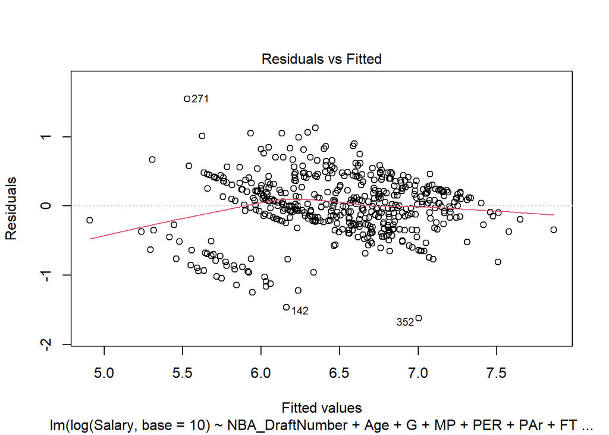

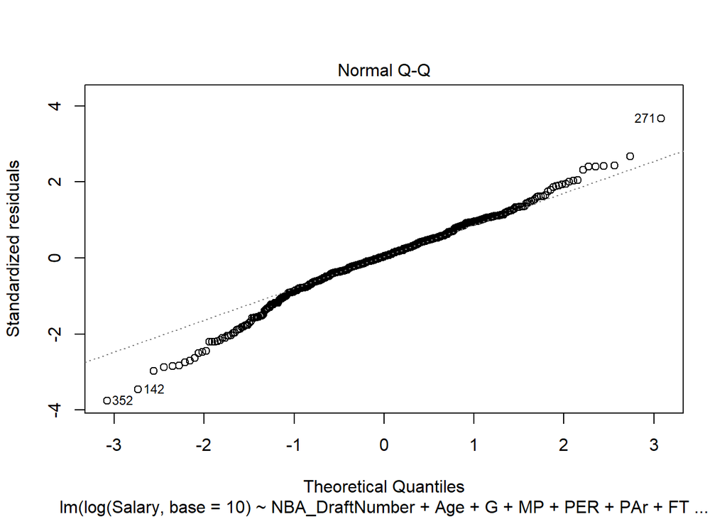

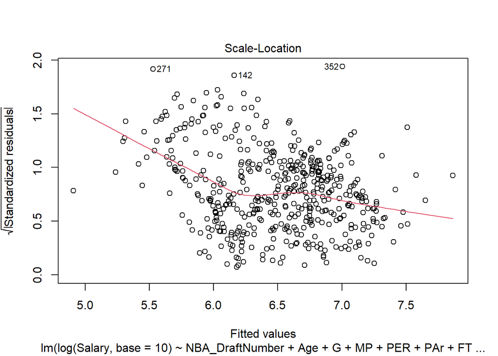

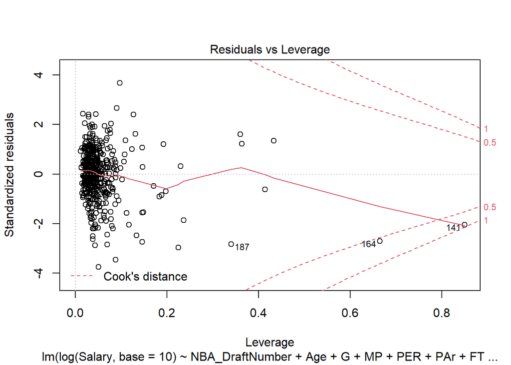

```r
plot(model)
```

```r
summary(model)
```

```
##
## Call:
## lm(formula = log(Salary, base = 10) ~ NBA_DraftNumber + Age +
##     G + MP + PER + PAr + FTr + ORB + DRB + TRB + AST + STL +
##     BLK + TOV + USG + OWS + DWS + WS + WS_1 + OBPM + DBPM + BPM +
##     VORP + Team + Pais, data = nba)
##
## Residuals:
##      Min       1Q   Median       3Q      Max
## -1.62529 -0.22805  0.01793  0.25919  1.54919
##
## Coefficients:
##                   Estimate Std. Error t value Pr(>|t|)
## (Intercept)      5.537e+00  2.960e-01  18.708  < 2e-16 ***
## NBA_DraftNumber -9.386e-03  1.108e-03  -8.469 3.41e-16 ***
## Age              4.384e-02  4.929e-03   8.893  < 2e-16 ***
## G               -1.310e-03  2.144e-03  -0.611  0.54151
## MP               3.702e-04  8.945e-05   4.139 4.16e-05 ***
## PER             -6.396e-02  2.417e-02  -2.647  0.00841 **
## PAr             -3.810e-01  1.939e-01  -1.965  0.05001 .
## FTr             -7.562e-02  7.584e-02  -0.997  0.31921
## ORB             -5.923e-02  7.792e-02  -0.760  0.44751
## DRB             -4.492e-02  7.740e-02  -0.580  0.56193
## TRB              1.260e-01  1.548e-01   0.814  0.41608
## AST              1.018e-03  3.685e-03   0.276  0.78258
## STL              3.569e-03  3.655e-02   0.098  0.92226
## BLK              1.638e-02  2.738e-02   0.598  0.54991
## TOV             -3.343e-03  4.062e-03  -0.823  0.41095
## USG              2.195e-02  8.631e-03   2.543  0.01130 *
## OWS             -2.644e-02  3.908e-01  -0.068  0.94609
## DWS             -9.417e-02  3.927e-01  -0.240  0.81060
## WS               3.626e-02  3.914e-01   0.093  0.92622
## WS_1             1.070e+00  9.194e-01   1.163  0.24524
## OBPM            -1.060e-01  4.097e-01  -0.259  0.79596
## DBPM            -1.499e-01  4.046e-01  -0.371  0.71110
## BPM              1.730e-01  4.058e-01   0.426  0.67007
## VORP            -1.087e-02  5.458e-02  -0.199  0.84228
## Team             3.729e-03  2.389e-03   1.561  0.11919
## Pais             3.113e-03  2.439e-03   1.276  0.20251
## ---
## Signif. codes:  0 '***' 0.001 '**' 0.01 '*' 0.05 '.' 0.1 ' ' 1
##
## Residual standard error: 0.4437 on 457 degrees of freedom
## Multiple R-squared:  0.5522, Adjusted R-squared:  0.5277
## F-statistic: 22.55 on 25 and 457 DF,  p-value: < 2.2e-16
```

### Conclusión Modelo General:

Respecto a las gráficas, en la gráfica **“Normal Q Q”**, se puede observar cómo los valores más alejados de la media tienden a tener una mayor dispersión respecto de la media. En la gráfica **“Scale-Location”** se puede observar como los valores se concentrar, aunque no de una manera evidente, en los valores centrales y su densidad tiende a disminuir a medida que se alejan del centro, lo que nos podría indicar una cierta heterocedasticidad. En la gráfica **“Residual vs Leverage”** podemos comprobar cómo hay ciertos valores que se alejan de los valores normales del modelo (outliers).

Por último, decir que R^2, el cual representa la bondad de ajuste del modelo, es de 0.5522, por lo que la roporción de la varianza total de la variable explicada por la regresión es del 55,22% sobre el total del modelo.

# Elección del modelo óptimo:

Varias son las maneras en las que se puede optimizar el modelo, pero para nuestro dataset se ha pensado que el Modelo del Critero de Informacion de Akaike (AIC) es el más óptimo para realizar nuestra elección.

El odelo del Critero de Informacion de Akaike (AIC), este modelo se caracteriza por una formulación simple y una fácil aplicación: una vez calculado el AIC para cada modelo se elige aquel cuyo AIC es mínimo. La solución dada por Akaike es elegir como función depérdida (o criterio de especificación) el mínimo del criterio de información AIC.

Se basa en la medida de información de Kullback-Leibler (1951), la cual permite interpretar la distancia entre dos distribuciones (en nuestro caso, la observada a partir de la muestra y la teórica) a partir de la log-verosimilitud de un modelo.

AIC = −2 ln(maxima verosimilitud) + 2(nº parametros independientemente ajustados)

```r
stepAIC(model, direction = 'both')
```

```
## Start:  AIC=-759.76
## log(Salary, base = 10) ~ NBA_DraftNumber + Age + G + MP + PER +
##     PAr + FTr + ORB + DRB + TRB + AST + STL + BLK + TOV + USG +
##     OWS + DWS + WS + WS_1 + OBPM + DBPM + BPM + VORP + Team +
##     Pais
##
##                   Df Sum of Sq     RSS     AIC
## - OWS              1    0.0009  89.959 -761.76
## - WS               1    0.0017  89.960 -761.75
## - STL              1    0.0019  89.960 -761.75
## - VORP             1    0.0078  89.966 -761.72
## - DWS              1    0.0113  89.970 -761.70
## - OBPM             1    0.0132  89.972 -761.69
## - AST              1    0.0150  89.974 -761.68
## - DBPM             1    0.0270  89.986 -761.62
## - BPM              1    0.0358  89.994 -761.57
## - DRB              1    0.0663  90.025 -761.41
## - BLK              1    0.0705  90.029 -761.38
## - G                1    0.0735  90.032 -761.37
## - ORB              1    0.1138  90.072 -761.15
## - TRB              1    0.1304  90.089 -761.06
## - TOV              1    0.1333  90.092 -761.05
## - FTr              1    0.1957  90.154 -760.71
## - WS_1             1    0.2665  90.225 -760.33
## - Pais             1    0.3206  90.279 -760.04
## <none>                          89.959 -759.76
## - Team             1    0.4797  90.438 -759.19
## - PAr              1    0.7601  90.719 -757.70
## - USG              1    1.2734  91.232 -754.97
## - PER              1    1.3789  91.337 -754.41
## - MP               1    3.3715  93.330 -743.99
## - NBA_DraftNumber  1   14.1186 104.077 -691.35
## - Age              1   15.5680 105.527 -684.67
##
## Step:  AIC=-761.76
## log(Salary, base = 10) ~ NBA_DraftNumber + Age + G + MP + PER +
##     PAr + FTr + ORB + DRB + TRB + AST + STL + BLK + TOV + USG +
##     DWS + WS + WS_1 + OBPM + DBPM + BPM + VORP + Team + Pais
##
##                   Df Sum of Sq     RSS     AIC
```

[output cut: 404 more lines]

```
## + DBPM             1    0.0736  90.929 -778.58
## + OBPM             1    0.0686  90.934 -778.55
## + VORP             1    0.0531  90.950 -778.47
## + STL              1    0.0499  90.953 -778.45
## + G                1    0.0367  90.966 -778.38
## + AST              1    0.0116  90.991 -778.25
## + BLK              1    0.0062  90.997 -778.22
## - WS_1             1    0.7776  91.780 -778.08
## - USG              1    1.9454  92.948 -771.97
## - PER              1    2.0807  93.084 -771.27
## - BPM              1    2.3696  93.372 -769.77
## - TRB              1    2.5906  93.593 -768.63
## - MP               1   10.5379 101.541 -729.27
## - NBA_DraftNumber  1   16.6311 107.634 -701.12
## - Age              1   17.2798 108.283 -698.22
```

```
##
## Call:
## lm(formula = log(Salary, base = 10) ~ NBA_DraftNumber + Age +
##     MP + PER + PAr + TRB + USG + DWS + WS_1 + BPM + Team + Pais,
##     data = nba)
##
## Coefficients:
##     (Intercept)  NBA_DraftNumber              Age               MP
##       5.2251187       -0.0098690        0.0447613        0.0003744
##             PER              PAr              TRB              USG
##      -0.0534943       -0.1731144        0.0222320        0.0249899
##             DWS             WS_1              BPM             Team
##      -0.0780952        1.3488727        0.0399818        0.0034677
##            Pais
##       0.0033241
```

```r
primer_filtro <- lm(formula = Salary ~ NBA_DraftNumber + Age + G + MP + PER +
               PAr + ORB + TRB + USG + WS + OBPM + Team, data = nba)
summary(primer_filtro)
```

```
##
## Call:
## lm(formula = Salary ~ NBA_DraftNumber + Age + G + MP + PER +
##     PAr + ORB + TRB + USG + WS + OBPM + Team, data = nba)
##
## Residuals:
##       Min        1Q    Median        3Q       Max
## -15450122  -2920599   -309805   2308305  21848404
##
## Coefficients:
##                   Estimate Std. Error t value Pr(>|t|)
## (Intercept)     -4617520.6  2826728.0  -1.634  0.10303
## NBA_DraftNumber   -62795.1    12249.9  -5.126 4.33e-07 ***
## Age               515217.3    54963.2   9.374  < 2e-16 ***
## G                -160364.0    21624.3  -7.416 5.68e-13 ***
## MP                  5269.4      848.7   6.209 1.17e-09 ***
## PER              -313881.5   141926.4  -2.212  0.02748 *
## PAr             -2975604.8  1683271.5  -1.768  0.07775 .
## ORB              -205941.1    92170.8  -2.234  0.02593 *
## TRB               337207.9   103253.2   3.266  0.00117 **
## USG               128666.8    56092.0   2.294  0.02224 *
## WS                825671.6   163048.6   5.064 5.91e-07 ***
## OBPM              540156.8   241494.6   2.237  0.02577 *
## Team               38621.5    26676.0   1.448  0.14834
## ---
## Signif. codes:  0 '***' 0.001 '**' 0.01 '*' 0.05 '.' 0.1 ' ' 1
##
## Residual standard error: 5051000 on 470 degrees of freedom
## Multiple R-squared:  0.5455, Adjusted R-squared:  0.5339
## F-statistic: 47.02 on 12 and 470 DF,  p-value: < 2.2e-16
```

### Análisis de multicolinealidad

La multicolinealidad se puede deber a una correlación alta entre las diferentes variables del modelo, por eso, a través del modelo VIF (Variance Inflation Factors), vamos a obtener la inflación de la varianza para modelos lienales con el fin de dilucidar qué variables osn menos representatitas y deben ser apartadas del modelo.

```r
vif(primer_filtro)
```

```
## NBA_DraftNumber             Age               G              MP             PER
##        1.264275        1.042863        5.400821        8.920559       29.111664
##             PAr             ORB             TRB             USG              WS
##        2.756189        3.369459        4.886947        2.018257        3.593194
##            OBPM            Team
##       27.867001        1.013322
```

```r
sqrt(vif(primer_filtro)) > 2
```

```
## NBA_DraftNumber             Age               G              MP             PER
##           FALSE           FALSE            TRUE            TRUE            TRUE
##             PAr             ORB             TRB             USG              WS
##           FALSE           FALSE            TRUE           FALSE           FALSE
##            OBPM            Team
##            TRUE           FALSE
```

```r
modelo_filtro_vif <- lm(formula = Salary ~ NBA_DraftNumber + Age + G +
               PAr + ORB + TRB + USG + WS + OBPM + Team, data = nba)
summary(modelo_filtro_vif)
```

```
##
## Call:
## lm(formula = Salary ~ NBA_DraftNumber + Age + G + PAr + ORB +
##     TRB + USG + WS + OBPM + Team, data = nba)
##
## Residuals:
##       Min        1Q    Median        3Q       Max
## -15660185  -3241957   -508106   2344188  21979326
##
## Coefficients:
##                 Estimate Std. Error t value Pr(>|t|)
## (Intercept)     -9610186    2320885  -4.141 4.10e-05 ***
## NBA_DraftNumber   -75479      12683  -5.951 5.19e-09 ***
## Age               508885      57380   8.869  < 2e-16 ***
## G                 -42639      13267  -3.214  0.00140 **
## PAr               -68251    1372903  -0.050  0.96037
## ORB              -195864      94267  -2.078  0.03827 *
## TRB               122146      87800   1.391  0.16483
## USG               151616      46240   3.279  0.00112 **
## WS               1476507     136658  10.804  < 2e-16 ***
## OBPM              -20506      55548  -0.369  0.71217
## Team               31890      27899   1.143  0.25359
## ---
## Signif. codes:  0 '***' 0.001 '**' 0.01 '*' 0.05 '.' 0.1 ' ' 1
##
## Residual standard error: 5291000 on 472 degrees of freedom
## Multiple R-squared:  0.4991, Adjusted R-squared:  0.4885
## F-statistic: 47.03 on 10 and 472 DF,  p-value: < 2.2e-16
```

## Validación:

Para poder validar el modelo, utilizaremos el paquete **GVLMA** (Global Validation of Linear Model Assumptions), la cual se encargará de realizar asunciones de modelos lineales, además de test direccionales diseñados para detectar skewness, kurtosis y heterocedasticidad.

```r
val_modelo <- gvlma(modelo_filtro_vif)
summary(val_modelo)
```

```
##
## Call:
## lm(formula = Salary ~ NBA_DraftNumber + Age + G + PAr + ORB +
##     TRB + USG + WS + OBPM + Team, data = nba)
##
## Residuals:
##       Min        1Q    Median        3Q       Max
## -15660185  -3241957   -508106   2344188  21979326
##
## Coefficients:
##                 Estimate Std. Error t value Pr(>|t|)
## (Intercept)     -9610186    2320885  -4.141 4.10e-05 ***
## NBA_DraftNumber   -75479      12683  -5.951 5.19e-09 ***
## Age               508885      57380   8.869  < 2e-16 ***
## G                 -42639      13267  -3.214  0.00140 **
## PAr               -68251    1372903  -0.050  0.96037
## ORB              -195864      94267  -2.078  0.03827 *
## TRB               122146      87800   1.391  0.16483
## USG               151616      46240   3.279  0.00112 **
## WS               1476507     136658  10.804  < 2e-16 ***
## OBPM              -20506      55548  -0.369  0.71217
## Team               31890      27899   1.143  0.25359
## ---
## Signif. codes:  0 '***' 0.001 '**' 0.01 '*' 0.05 '.' 0.1 ' ' 1
##
## Residual standard error: 5291000 on 472 degrees of freedom
## Multiple R-squared:  0.4991, Adjusted R-squared:  0.4885
## F-statistic: 47.03 on 10 and 472 DF,  p-value: < 2.2e-16
##
##
## ASSESSMENT OF THE LINEAR MODEL ASSUMPTIONS
## USING THE GLOBAL TEST ON 4 DEGREES-OF-FREEDOM:
## Level of Significance =  0.05
##
## Call:
##  gvlma(x = modelo_filtro_vif)
##
##                      Value   p-value                   Decision
## Global Stat        90.9481 0.000e+00 Assumptions NOT satisfied!
## Skewness           39.6768 2.997e-10 Assumptions NOT satisfied!
## Kurtosis           43.1521 5.065e-11 Assumptions NOT satisfied!
## Link Function       7.3783 6.601e-03 Assumptions NOT satisfied!
## Heteroscedasticity  0.7409 3.894e-01    Assumptions acceptable.
```

El resultado obtenido tras esta validación no es el deseado a la hora de poder validar el modelo, ya que la única asunción que se puede aceptar es el de la Heterocedasticidad. Este modelo presenta Kurtosis, Skewness y Link Function aunque cuente con un R^2 de 0.4991.